[figure not shown]

##### Models for Socio-Environmental Data

##### Probability Lab 3: Marginal Distributions

##### December 15, 2020

### **Motivation**

The guiding purpose in Bayesian analysis is to discover the *marginal posterior distribution* of unobserved quantities (parameters, latent states, missing data, forecasts) from quantities we are able to observe (data). It follows that we must understand what marginal distributions are. The following is an example of a discrete case that also exercises your newly gained familiarity with the laws of probability.

### **R libraries needed for this lab**

You need to load the following library. Set the seed to 10 to compare your answers to ours.

```r
library(MASS)
set.seed(10)
```

### **Discrete random variables: Diamonds Pigeons**

Jared Diamond studied the distribution of fruit pigeons *Ptilinopus rivoli* and *P. solomonensis* on 32 islands in the Bismark archipelago northeast of New Guinea (Table 1). Define the event $R$ as an island being occupied by *P. rivoli*, and the event $S$ as an island being occupied by *P. solomonensis*. The complementary events are that an island is not occupied by *P. solomonensis* $\big(S^c\big)$ and not occupied by *P. rivoli* $\big(R^c\big)$.

**Table 1**: Data on distribution of species of fruit pigeons on islands

| Status | Number of Islands |
| --- | --- |
| *P. rivoli* present, *P. solomonensis* absent | 9 |
| *P. solomonensis* present, *P. rivoli* absent | 18 |
| Both present | 2 |
| Both absent | 3 |
| Total | 32 |

1. Fill in Table 2 to estimate the *marginal* probabilities of presence and absence of the two species. The cells show the joint probability of the events specified in the row and column. The right column and the bottom row show the marginal probabilities.
1. What is the sum of the marginal rows?
2. What is the sum of the marginal columns?
3. Why? Note, when we marginalize over $R$ we are effectively eliminating $S$ and vice versa.

**Table 2**: Estimates of marginal probabilities for island occupancy

| Events | $S$ | $S^c$ | Marginal |
| --- | --- | --- | --- |
| $R$ | $\Pr\big(S,R\big)=$ | $\Pr\big(S^c, R\big) =$ | $\Pr\big(R\big)=$ |
| $R^c$ | $\Pr\big(S,R^c\big)=$ | $\Pr\big(S^c, R^c\big) =$ | $\Pr\big(R^c\big)=$ |
| Marginal | $\Pr\big(S\big)=$ | $Pr\big(S^c\big)=$ | $\sum=$ |

**Table 2**: Estimates of marginal probabilities for island occupancy

| Events | $S$ | $S^c$ | Marginal |
| --- | --- | --- | --- |
| $R$ | $\Pr\big(S,R\big)=\frac{2}{32}$ | $\Pr\big(S^c, R\big) =\frac{9}{32}$ | $\Pr\big(R\big)=\frac{11}{32}$ |
| $R^c$ | $\Pr\big(S,R^c\big)=\frac{18}{32}$ | $\Pr\big(S^c, R^c\big)=\frac{3}{32}$ | $\Pr\big(R^c\big)=\frac{21}{32}$ |
| Marginal | $\Pr\big(S\big)=\frac{20}{32}$ | $Pr\big(S^c\big)=\frac{12}{32}$ | $=\frac{32}{32}$ |

2. Use the data in Table 1 and the probabilities in Table 2 to illustrate the rule for the union of two events, the probability that an island contains either species, $\Pr\big(R\cup S\big)$. You will need to derive the formula for the probability of event A or B to solve this problem. A Venn diagram might help you do so.

$$\begin{eqnarray}
\Pr\big(R\cup S\big) & = & \Pr\big(R\big) + \Pr\big(S\big) - \Pr\big(S,R\big)\\[1em]
\Pr\big(R\big) & = &\frac{11}{32}\\[1em]
\Pr\big(S\big) & = &\frac{20}{32}\\[1em]
\Pr\big(R,S\big) & = &\frac{2}{32}\\[1em]
\Pr\big(R\cup S\big) & = & \frac{11+20-2}{32} = \frac{29}{32}\\[1em]
\end{eqnarray}$$

3. Use the marginal probabilities in Table 2 to calculate the probability that an island contains both species i.e., $\Pr\big(R,S\big)$, assuming that $R$ and $S$ are independent. Compare the results from those calculations with the probability that both species occur on an island calculated directly from the data in Table 1. Interpret the results ecologically. What is $\Pr\big(R\mid S\big)$? What is $\Pr\big(S\mid R\big)$?

If the probabilities are independent, then:

$$\Pr\big(R,S\big) = \Pr\big(R\big)\Pr\big(S\big) = \frac{20}{32}\frac{11}{32} = .215$$

Based on the data in Table 1, the probability that an island is occupied by both species is $\frac{2}{32}=.062$. Diamond interpreted this difference as evidence of niche separation resulting for inter-specific competition, an interpretation that stimulated a decade of debate. The conditional probabilities, $\Pr\big(R\mid S\big)$ and $\Pr\big(S \mid R\big)$ are:

$$\begin{eqnarray}
\Pr\big(R \mid S\big) &=& \cfrac{\Pr\big(R,S\big)}{\Pr\big(S\big)}=\cfrac{\frac{2}{32}}{\frac{20}{32}}=.10\\[2em]
\Pr\big(S \mid R\big) &=& \cfrac{\Pr\big(R,S\big)}{\Pr\big(R\big)}=\cfrac{\frac{2}{32}}{\frac{11}{32}}=.18\\[2em]
& & \\[1em]
\end{eqnarray}$$

### **Continuous random variables**

We now explore marginal distributions for continuous random variables. This requires introducing a new distribution, the multivariate normal:

$$\mathbf{z} \sim \text{multivariate normal}({\pmb{\mu}, \pmb{\Sigma}} ),$$

where $\mathbf{z}_i$ is a vector of random variables, $\pmb{\mu}$ is a vector of means (which can be the output of a deterministic model) and $\pmb\Sigma$ is a variance covariance matrix. The diagonal of $\pmb\Sigma$ contains the variances and the off diagonal contains the covariance of $\Sigma[i,j]$. The covariance can be calculated as $\sigma_i\sigma_j\rho$ where $\sigma_i$ is the standard deviation of the $ith$ random variable, $\sigma_j$ is the standard deviation of the $jth$ random variable, and $\rho$ is the correlation between the random variable $i$ and $j$. The covariance matrix is square and symmetric. We will learn more about these matrices later in the course. For now, an example will go a long way toward helping you understand the multivariate normal distribution.

The rate of inflation and the rate of return on investments are know to be positively correlated. Assume that the mean rate of inflation is .03 with a standard deviation of 0.015. Assume that the mean rate of return is 0.0531 with a standard deviation of 0.0746. Assume the correlation between inflation and rate of return is 0.5.

You can simulate interest rate and inflation data reflecting their correlation using the following function:

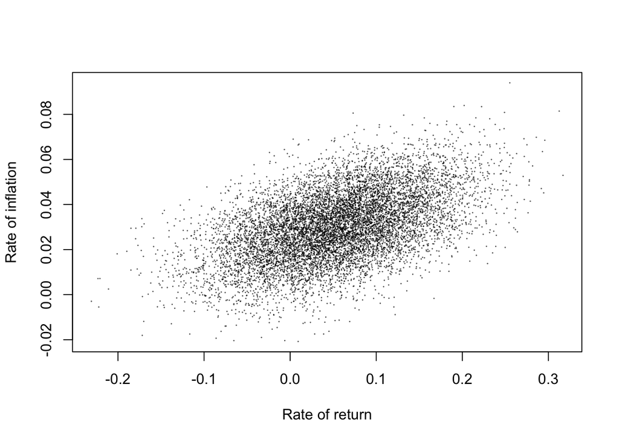

```r
DrawRates = function(n, int,int.sd, inf, inf.sd, rho.rates) {
  covar = rho.rates * int.sd * inf.sd
  Sigma <- matrix(c(int.sd^2, covar, covar, inf.sd^2), 2, 2)
  mu = c(int,inf)
  x = (mvrnorm(n = n, mu = mu, Sigma))
  return(x)
}

mu.int = .0531
sd.int = .0746
mu.inf = .03
sd.inf = .015
rho=.5
n = 10000

x = DrawRates(n = n, int = mu.int, int.sd = sd.int, inf = mu.inf, inf.sd = sd.inf, rho.rates = rho)

plot(x[, 1], x[, 2], pch = 19, cex = .05, xlab = "Rate of return", ylab = "Rate of inflation")
```

What would this cloud look like if the rates were not correlated?

Show an approximate plot of the marginal distribution of each random variable. It turns out this is the way we will do it with MCMC.

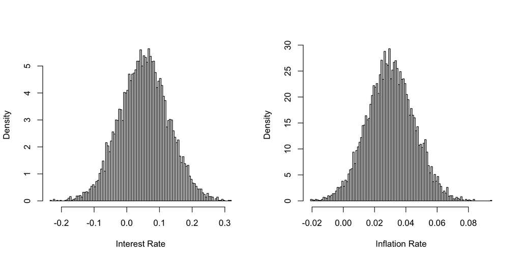

```r
par(mfrow = c(1, 2))
hist(x[, 1], xlab = "Interest Rate", main = "", freq = FALSE, breaks = 100)
hist(x[, 2], xlab = "Inflation Rate", main = "", freq = FALSE, breaks = 100)
```